# DANL 310 Lecture 06

February 15, 2022

## Show me the right number

## Loading the R packages

```r
library(tidyverse)
```

```r
library(skimr)   # a better summary of data frame
library(scales)  # scales for ggplot
library(gapminder) # gapminder data
library(socviz)  # data for visualization practice
```

## Facet to make small multiples

```r
p <- ggplot(data = gapminder,
            mapping = aes(x = year,
                          y = gdpPercap))

p + geom_line(color="gray70", aes(group = country)) +
    geom_smooth(size = 1.1, method = "loess", se = FALSE) +
    scale_y_log10(labels=scales::dollar) +
    facet_wrap(~ continent, ncol = 5) +
    labs(x = "Year", y = "GDP per capita",
         title = "GDP per capita on Five Continents") +
    theme(axis.text.x = element_text(angle = 45),
          axis.title.x = element_text(margin = margin(t = 20)))
```

- The `facet_wrap()` function is best used when you want a series of small multiples based on a single categorical variable.

## Facet to make small multiples

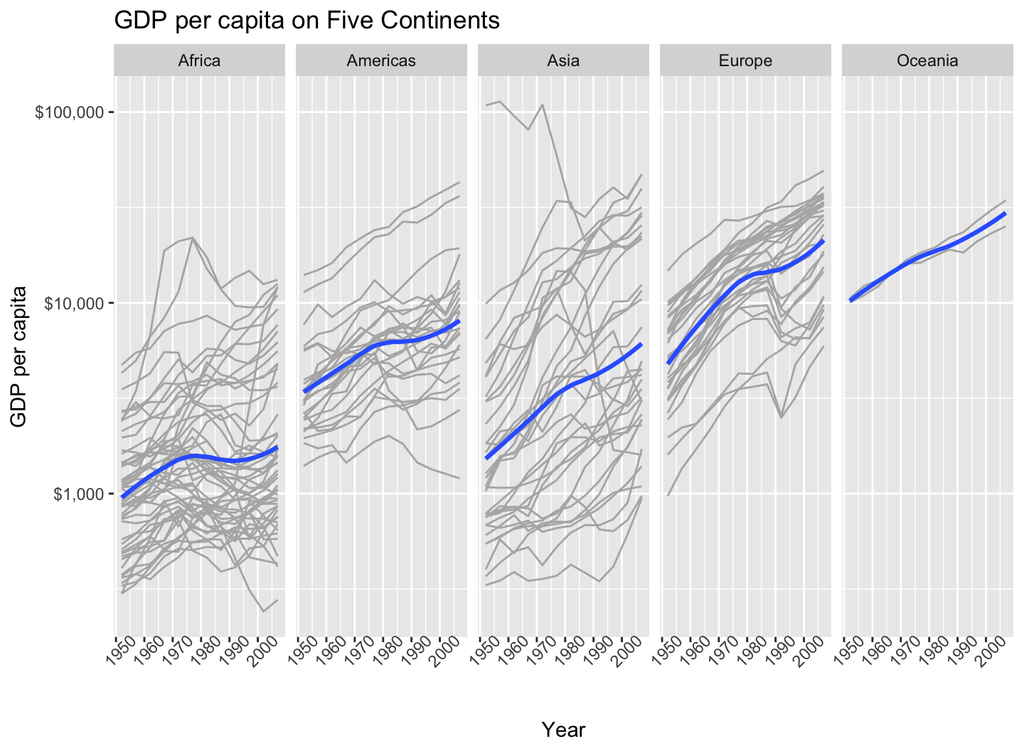

## The 2016 General Social Survey data

- The `socviz` package includes the `gss_sm` data frame.
  - `gss_sm` is a dataset containing an extract from the 2016 General Social Survey.

```r
?gss_sm
glimpse(gss_sm)
skim(gss_sm)
view(gss_sm)
```

## Facet to make small multiples

```r
p <- ggplot(data = gss_sm,
            mapping = aes(x = age, y = childs))

p + geom_point(alpha = 0.2) +
    geom_smooth() +
    facet_grid(sex ~ race)
```

- The `facet_grid()` function is best used when you cross-classify some data by two categorical variables.
  - e.g., the relationship between the age and the number of children by sex and race

## Facet to make small multiples

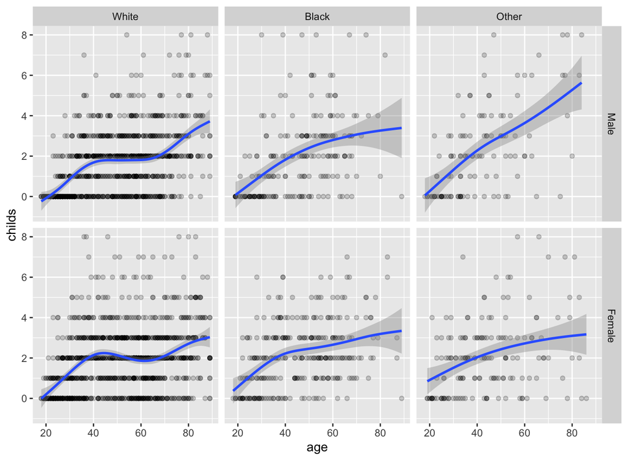

## Geoms can transform data

```r
p <- ggplot(data = gss_sm,
            mapping = aes(x = bigregion))
p + geom_bar()
```

- The `count` statistic is the one `geom_bar()` uses by default.

## Geoms can transform data

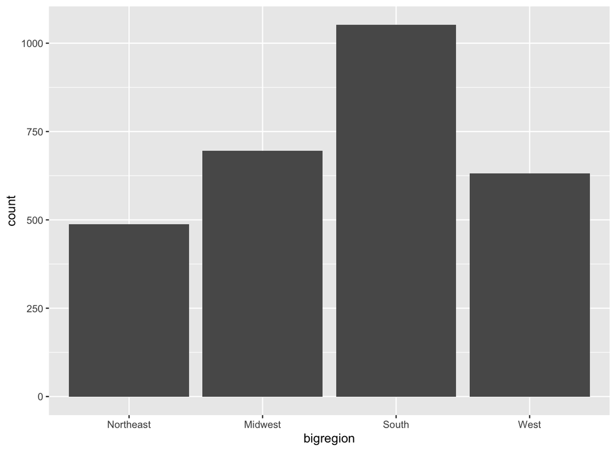

## Geoms can transform data

```r
p <- ggplot(data = gss_sm,
            mapping = aes(x = bigregion))
p + geom_bar(mapping = aes(y = ..prop..))
```

- If we want a chart of relative frequencies rather than counts, we will need to get the `prop` statistic instead.
- Our call to statistic from the `aes()` function generically looks like this: `<mapping> = <..statistic..>`.

## Geoms can transform data

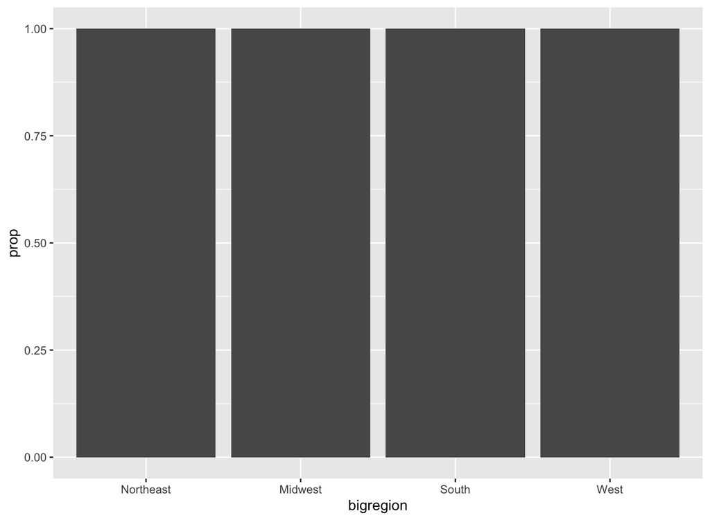

## Geoms can transform data

```r
p <- ggplot(data = gss_sm,
            mapping = aes(x = bigregion))
p + geom_bar(mapping = aes(y = ..prop.., group = 1))
```

- We need to tell ggplot to ignore the x-categories when calculating denominator of the proportion, and use the total number observations instead.
  - To do so we specify `group = 1` inside the `aes()` call.

## Geoms can transform data

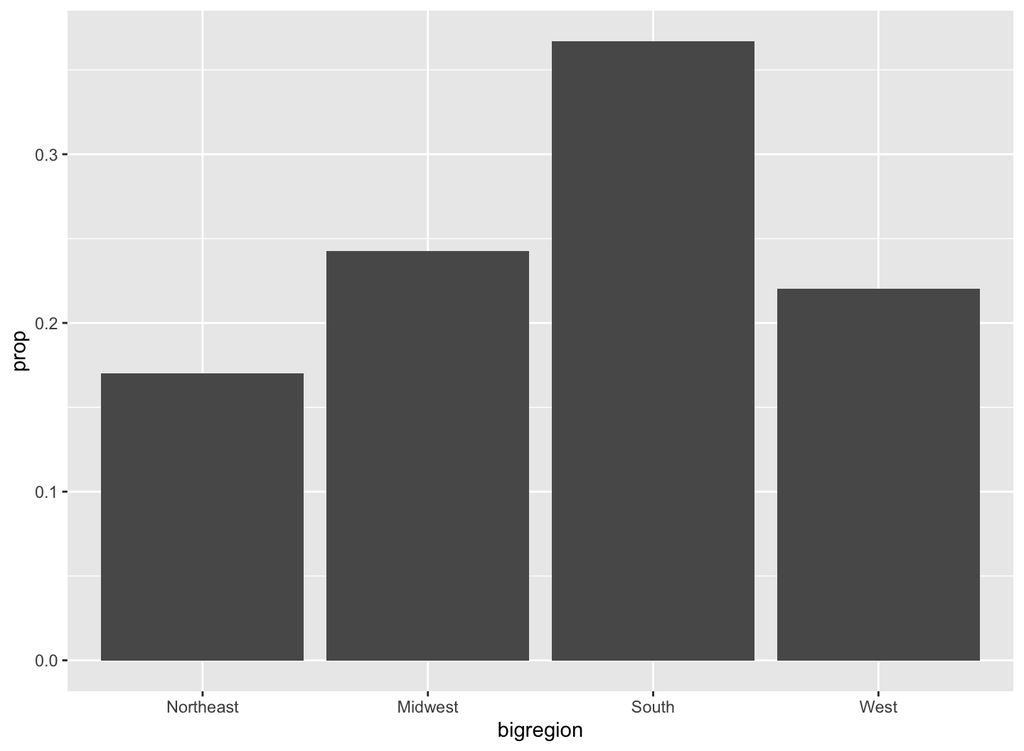

## Geoms can transform data

```r
table(gss_sm$religion)
```

```
##
## Protestant   Catholic     Jewish       None      Other
##       1371        649         51        619        159
```

## Geoms can transform data

```r
p <- ggplot(data = gss_sm,
            mapping = aes(x = religion, color = religion))
p + geom_bar()
```

- If we map religion to `color`, only the border lines of the bars will be assigned colors, and the insides will remain gray.

## Geoms can transform data

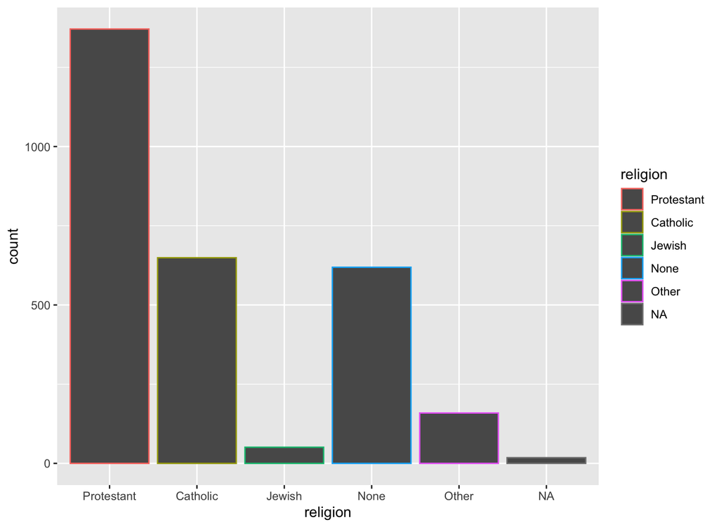

## Geoms can transform data

```r
p <- ggplot(data = gss_sm,
            mapping = aes(x = religion, fill = religion))
p + geom_bar() + guides( fill = "none" )
```

- If the gray bars look boring and we want to fill them with color instead, we can map the religion variable to `fill` in addition to mapping it to `x`.
- The default legend is about the color variable, which is redundant.
  - If we set `guides(fill = "none")`, the legend is removed.

## Geoms can transform data

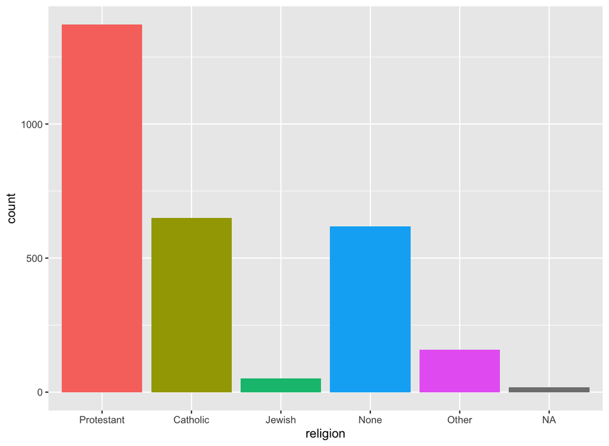

## Frequency plots the slightly awkward way

```r
p <- ggplot(data = gss_sm,
            mapping = aes(x = bigregion, fill = religion))
p + geom_bar()
```

- A more appropriate use of the `fill` aesthetic with `geom_bar()` is to cross-classify two categorical variables.
  - The default output of such `geom_bar()` is a stacked bar chart, with counts on the y-axis.

## Frequency plots the slightly awkward way

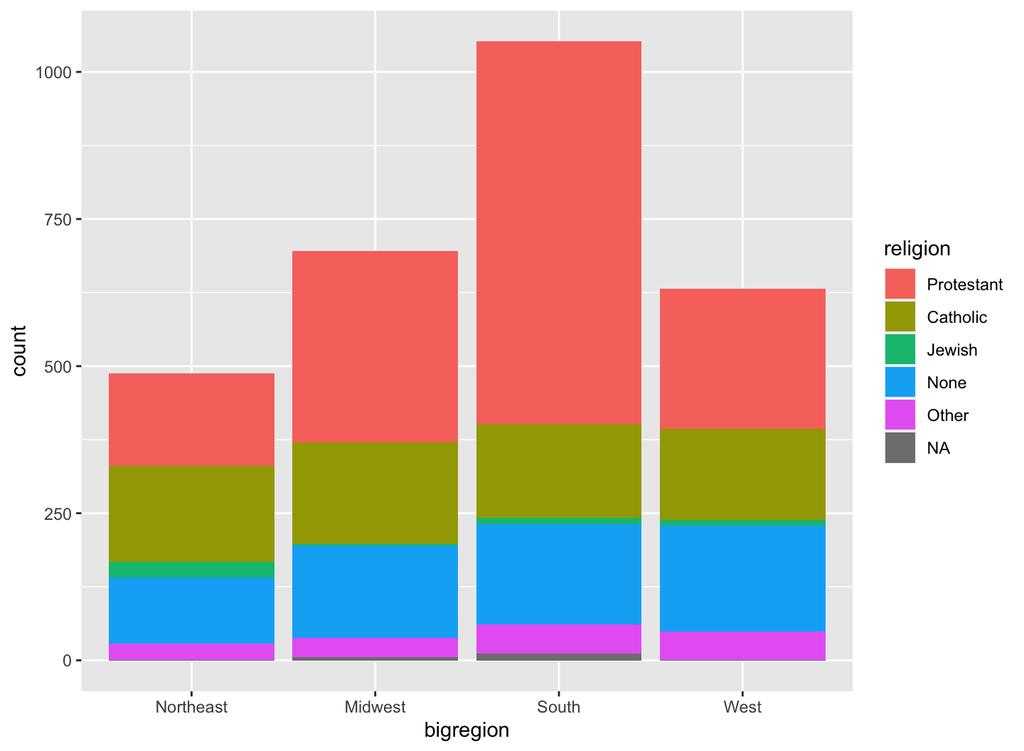

## Frequency plots the slightly awkward way

```r
p <- ggplot(data = gss_sm,
            mapping = aes(x = bigregion, fill = religion))
p + geom_bar(position = "fill")
```

- An alternative choice is to set the position argument to `"fill"`.
  - It is to compare proportions across groups.

## Frequency plots the slightly awkward way

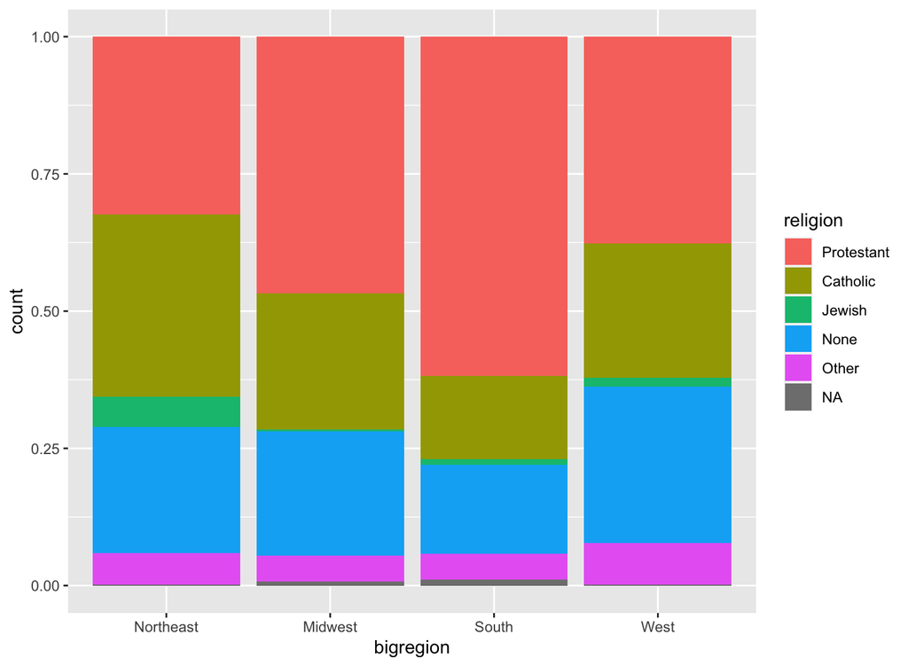

## Frequency plots the slightly awkward way

```r
p <- ggplot(data = gss_sm,
            mapping = aes(x = bigregion, fill = religion))
p + geom_bar(position = "dodge",
             mapping = aes(y = ..prop..))
```

- We can use `position="dodge"` to make the bars within each region of the country appear side by side.

## Frequency plots the slightly awkward way

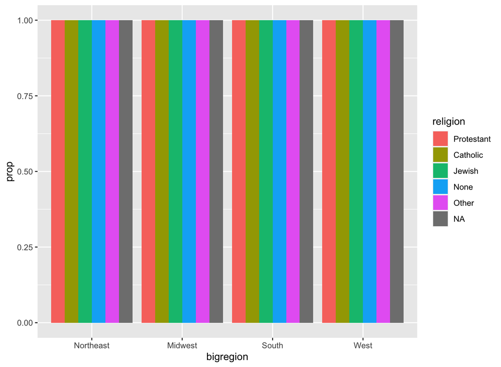

## Frequency plots the slightly awkward way

```r
p <- ggplot(data = gss_sm,
            mapping = aes(x = bigregion, fill = religion))
p + geom_bar(position = "dodge",
             mapping = aes(y = ..prop.., group = religion))
```

- In this case our grouping variable is `religion`, so we might try mapping that to the `group` aesthetic.

## Frequency plots the slightly awkward way

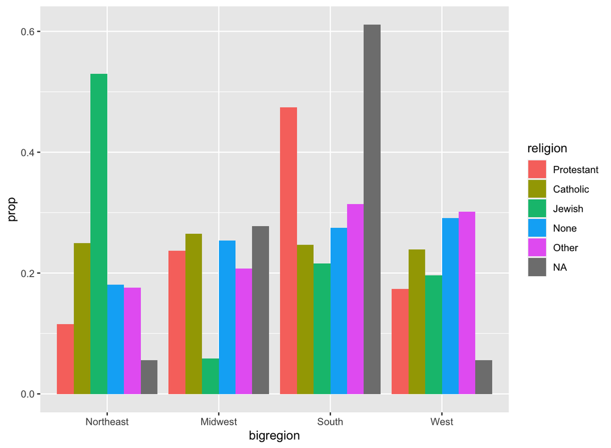

## Frequency plots the slightly awkward way

```r
p <- ggplot(data = gss_sm,
            mapping = aes(x = religion))
p + geom_bar(position = "dodge",
             mapping = aes(y = ..prop.., group = bigregion)) +
    facet_wrap(~ bigregion, ncol = 1)
```

- Instead, we can ask ggplot to give us a proportional bar chart of religious affiliation, and then facet that by region.
  - The proportions are calculated within each panel, which is the breakdown we wanted.

## Frequency plots the slightly awkward way

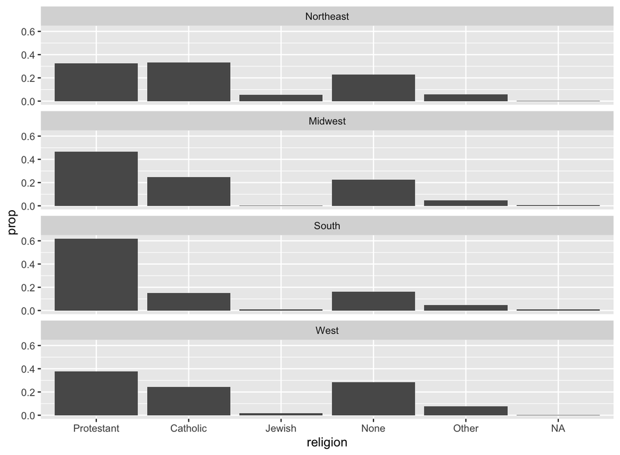

## Midwest demographics

```r
?midwest
glimpse(midwest)
skim(midwest)
view(midwest)
```

- The `ggplot` package comes with a dataset, `midwest`, containing information on counties in several midwestern states of the USA.

## Histograms and density plots

```r
p <- ggplot(data = midwest,
            mapping = aes(x = area))
p + geom_histogram()
```

- By default, the `geom_histogram()` function will choose a bin size for us based on a rule of thumb.

## Histograms and density plots

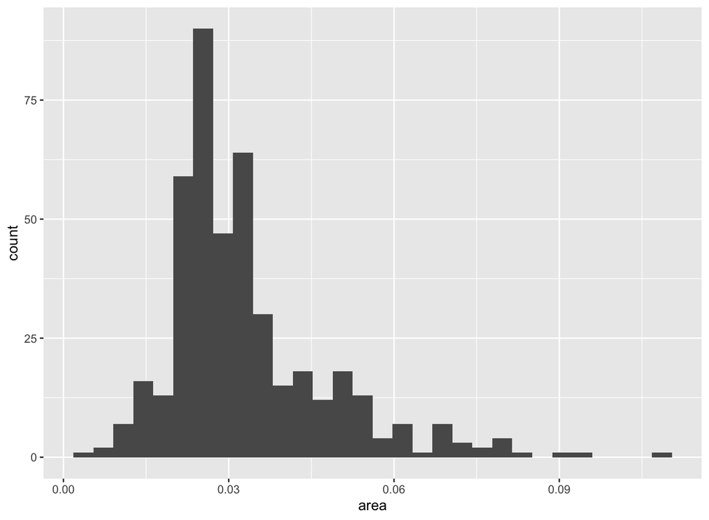

## Histograms and density plots

```r
p <- ggplot(data = midwest,
            mapping = aes(x = area))
p + geom_histogram(bins = 10)
```

- When drawing histograms it is worth experimenting with `bins` and also optionally the `origin` of the x-axis.

## Histograms and density plots

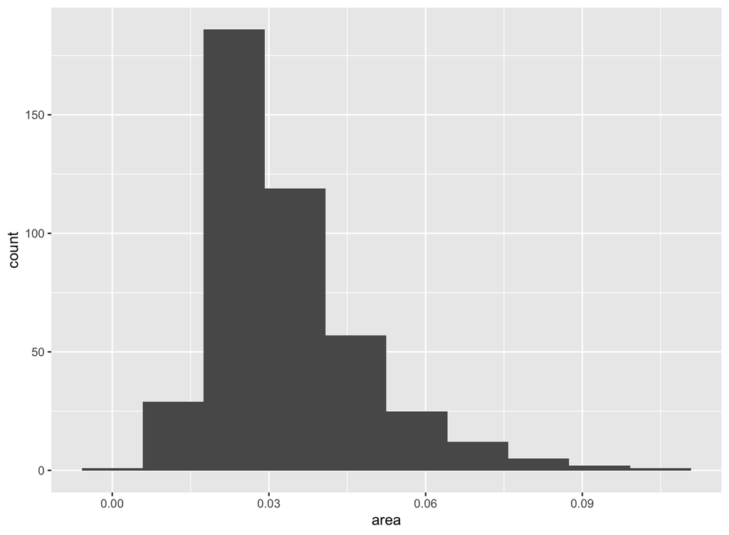

## Histograms and density plots

```r
oh_wi <- c("OH", "WI")

p <- ggplot(data = subset(midwest, subset = state %in% oh_wi),
            mapping = aes(x = percollege, fill = state))
p + geom_histogram(alpha = 0.4, bins = 20)
```

- We can facet histograms by some variable of interest, or as here we can compare them in the same plot using the `fill` mapping.
  - We subset the data here to pick out just two states.
  - The `%in%` operator is a convenient way to filter on more than one term in a variable when using `subset()`

## Histograms and density plots

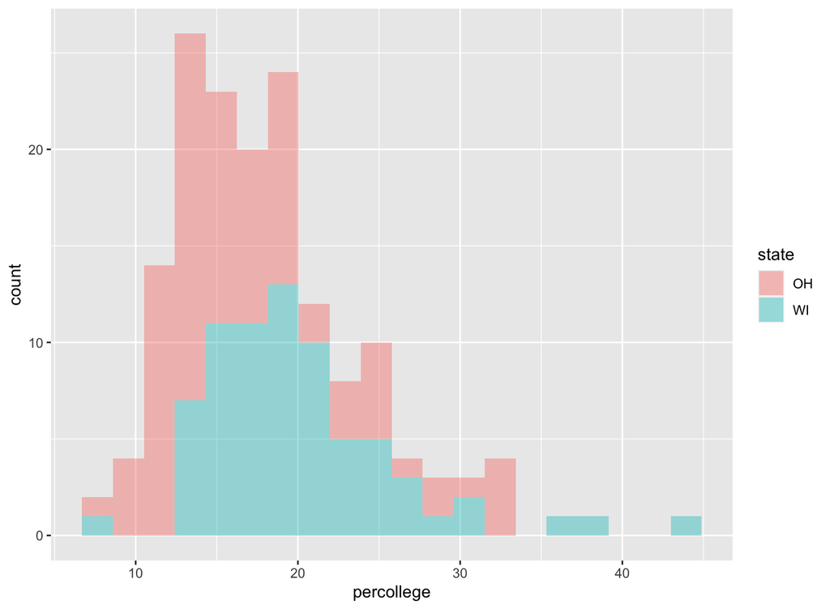

## Histograms and density plots

```r
p <- ggplot(data = midwest,
            mapping = aes(x = area))
p + geom_density()
```

- When working with a continuous variable, an alternative to binning the data and making a histogram is using the `geom_density()` function.
  - It calculates a kernel density estimate of the underlying distribution.
  - The area under the whole curve is usually 1.

## Histograms and density plots

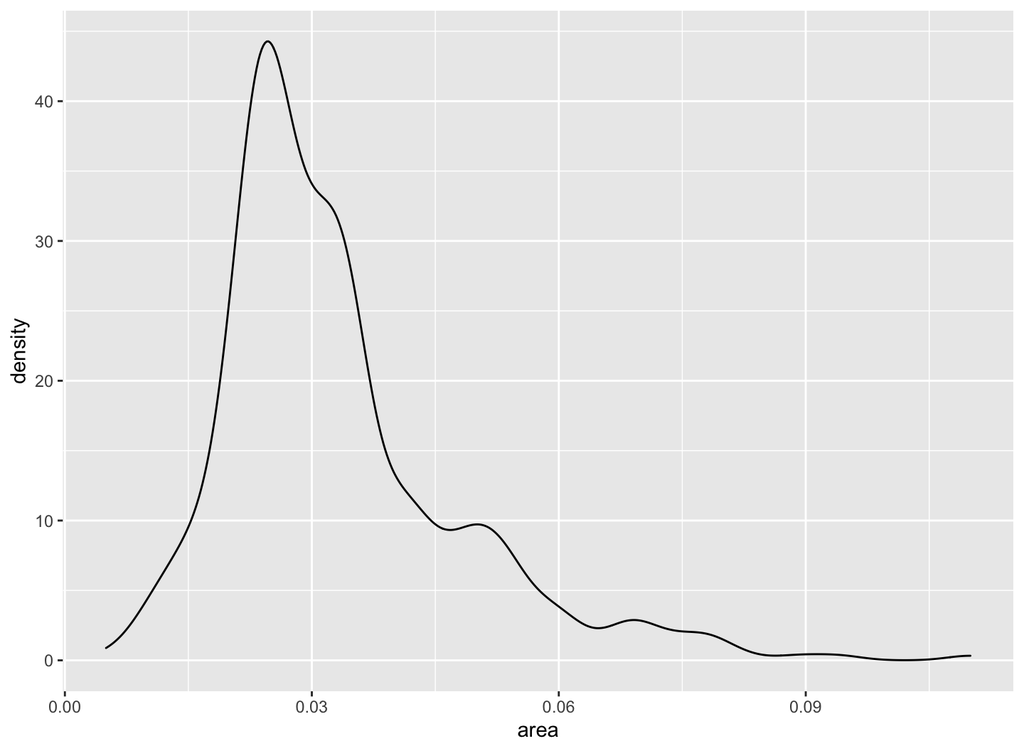

## Histograms and density plots

```r
p <- ggplot(data = midwest,
            mapping = aes(x = area, fill = state, color = state))
p + geom_density(alpha = 0.3)
```

- We can use `color` (for the lines) and `fill` (for the body of the density curve).
  - These figures often look quite nice.
  - When there are several filled areas on the plot, as in this case, the overlap can become hard to read.

## Histograms and density plots

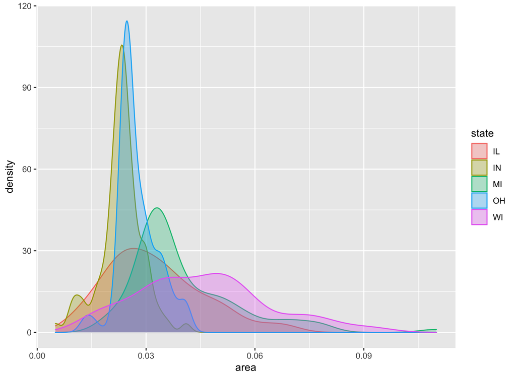

## Histograms and density plots

```r
oh_wi <- c("OH", "WI")
p <- ggplot(data = subset(midwest, subset = state %in% oh_wi),
            mapping = aes(x = area, fill = state, color = state))
p + geom_density(alpha = 0.3, mapping = (aes(y = ..scaled..)))
```

- For `geom_density()`, the `stat_density()` function can return its default `..density..` statistic, or `..scaled..`, which will give a proportional density estimate.
- It can also return a statistic called `..count..`, which is the density times the number of points. This can be used in stacked density plots.

## Histograms and density plots

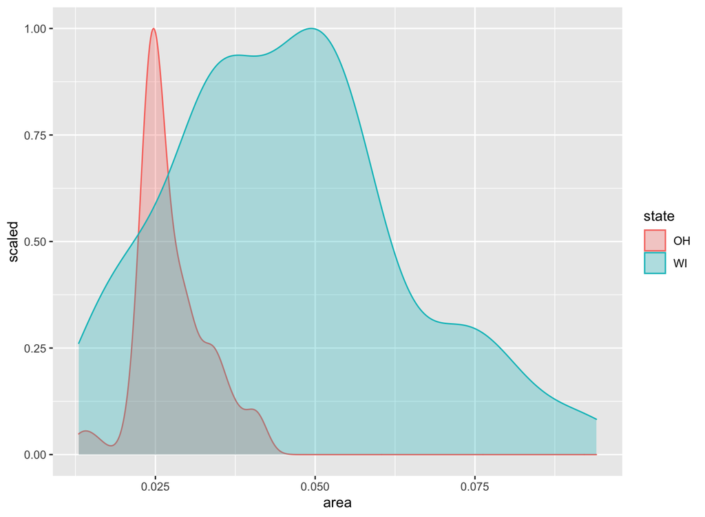

## Titanic data

- The `socviz` package includes the `titanic` data frame.
  - the aggregated data on who survived the Titanic disaster by sex.

```r
?titanic
titanic
```

```
##       fate    sex    n percent
## 1 perished   male 1364    62.0
## 2 perished female  126     5.7
## 3 survived   male  367    16.7
## 4 survived female  344    15.6
```

## Avoid transformations when necessary

```r
p <- ggplot(data = titanic,
            mapping = aes(x = fate, y = percent, fill = sex))

p + geom_bar(position = "dodge", stat = "identity") + theme(legend.position = "top")
```

- We can tell `geom_bar()` not to do any work on the variable before plotting it.
  - `stat = "identity"` means “don’t do any summary calculations”.

## Avoid transformations when necessary

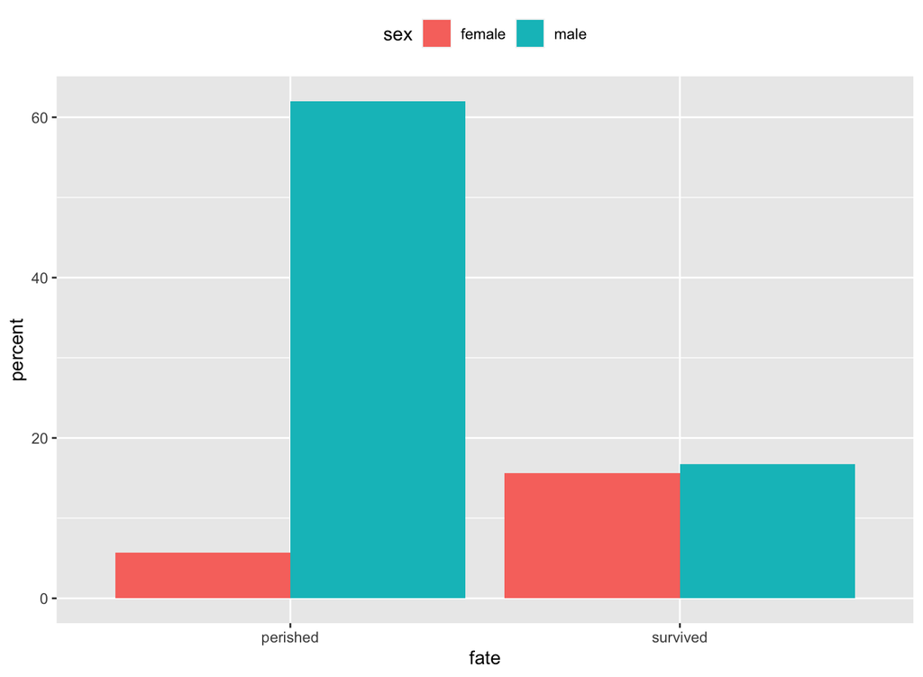

## OECD data

- The `socviz` package also includes the `oecd_sum` data frame.
  - The `oecd_sum` table information on average life expectancy at birth within the United States, and across other OECD countries.

```r
?oecd_sum
oecd_sum
```

```
## # A tibble: 57 × 5
## # Groups:   year [57]
##     year other   usa  diff hi_lo
##    <int> <dbl> <dbl> <dbl> <chr>
##  1  1960  68.6  69.9 1.30  Below
##  2  1961  69.2  70.4 1.20  Below
##  3  1962  68.9  70.2 1.30  Below
##  4  1963  69.1  70   0.900 Below
##  5  1964  69.5  70.3 0.800 Below
##  6  1965  69.6  70.3 0.700 Below
##  7  1966  69.9  70.3 0.400 Below
##  8  1967  70.1  70.7 0.600 Below
##  9  1968  70.1  70.4 0.300 Below
## 10  1969  70.1  70.6 0.5   Below
## # … with 47 more rows
```

## Avoid transformations when necessary

```r
p <- ggplot(data = oecd_sum,
            mapping = aes(x = year, y = diff, fill = hi_lo))
p + geom_col() + guides( fill = "none" ) +
  labs(x = NULL, y = "Difference in Years",
       title = "The US Life Expectancy Gap",
       subtitle = "Difference between US and OECD
                   average life expectancies, 1960-2015",
       caption = "Data: OECD. After a chart by Christopher Ingraham,
                  Washington Post, December 27th 2017.")
```

- For convenience `ggplot` also provides a related geom, `geom_col()`, which has exactly the same effect as `geom_bar()` but its default `stat` is `stat = "identity"`.
- The `position` argument in `geom_bar()` and `geom_col()` can also take the value of `"identity"`.
  - `position = "identity"` means “just plot the values as given”.

## Avoid transformations when necessary

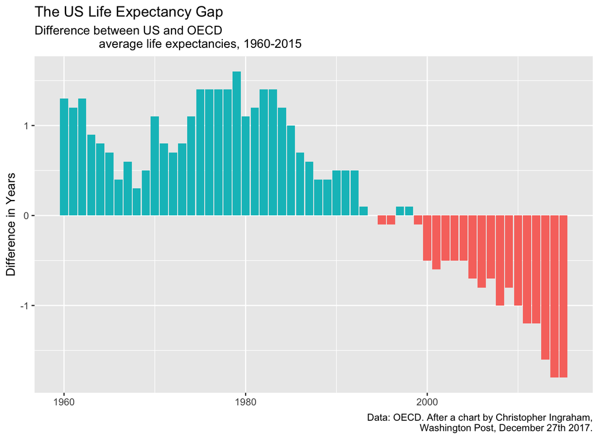